# Test yourself 05

Rate your confidence of being able to answer the below questions saying A, B or C, where:

- A. I am confident that I know the answer to this question
- B. I know at least 50% of the answer to this question, within 20 minutes I could find the required resources to enable a complete answer
- C. I am not confident that I can answer the question at this time.

### Part I (Rating confidence)

1. Could you broadly explain the concept and application of likelihood?
2. In Bayesian approach, could you broadly explain the difference between the prior and posterior distribution?
3. Can you broadly explain the concept of AIC and relative Likelihood?
4. In feature selection, could you explain the concept of Lasso?
5. In ANN, could you explain what an activation function is?
6. In ANN, could you explain gradient descent?
7. Do you understand the forward pass in a (very) simple ANN?
8. Would you be able to explain the structure of a given feedforward neural network?

### Part II (Answer questions: matching the confidence questions above)

1. What is not correct about likelihood?
   1. likelihood is a generative model
   2. likelihood can be used to estimate how likely it is that a certain model parameter values are true
   3. in linear models, the maximum likelihood estimates are the same least squares estimates
   4. maximum likelihood equates the conditional probability of model parameters given the observed data
2. In Bayesian approach, what is true about the prior and posterior distribution?
   1. prior distribution reflects what we already know about the value of the parameter of interest, the posterior distribution captures our prior knowledge and knowledge coming from observing the data
   2. posterior distribution reflects what we know about the value of the parameter of interest, the prior distribution captures our prior knowledge and knowledge coming from observing the data
   3. prior distribution and posterior distributions are completely unrelated, the prior is used to capture a hypothetical distribution of the model parameter, the posterior captures the knowledge after getting to know the data
   4. none of the above is true
3. For AIC, which of the following statements is *not* true
   1. the relative likelihood, $relL$, can be used to compare models
   2. AIC is a method to address over-fitting
   3. AIC for a model penalizes the maximum logLikelihood with the number of variables in the model
   4. AIC for a model penalizes the maximum likelihood with the number of variables in the model
4. In feature selection, what is *not* true about Lasso?
   1. LASSO stands for least absolute shrinkage and selection operator
   2. LASSO can be viewed as least squares model parameters estimation that includes a penalty criterion
   3. LASSO can be viewed as a (un-normalized) Bayesian posterior probability
   4. LASSO results in an overfitted model
5. In ANN, what is *not* true about the activation function?
   1. activation function determines the output of neuron in a neural network
   2. the sigmoid activation function normalizes the output of each neuron to 0 - 1 range
   3. the logistic function is an example of an activation function
   4. activation function activates learning in ANN
6. In ANN, what is true about gradient descent?
   1. gradient descent is used during the back-propagation step to compute partial derivatives
   2. gradient descent is calculated based on partial derivatives of the loss function
   3. gradient descent is used in forward pass to update model parameters
   4. gradient descent depends on the learning rate
7. In the ANN below, what is true about the result of a forward pass?
   1. $y = 0.61$
   2. $\hat{y} = 0.61$
   3. $\hat{y} = a_1$
   4. $x = 0.61$

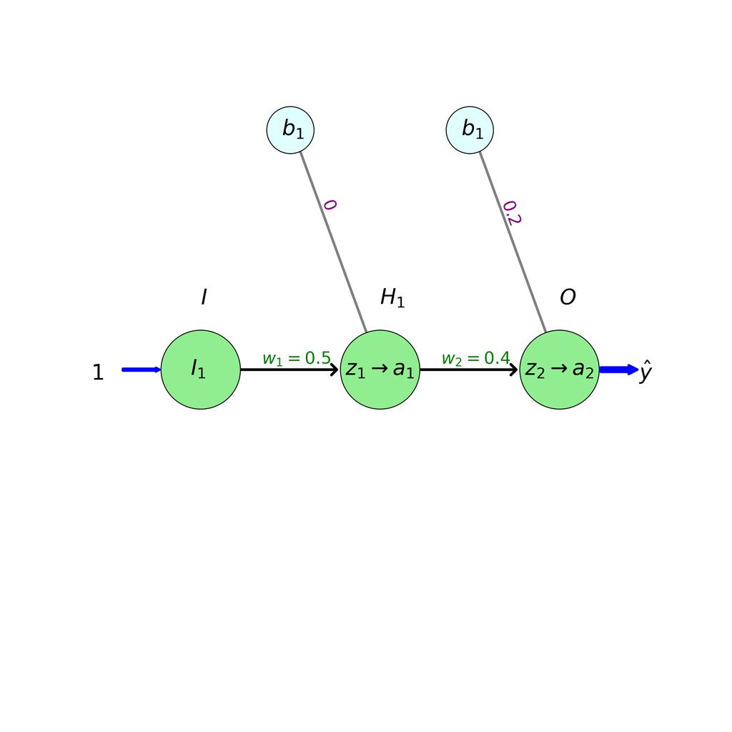

8. What is true about the structure of the below neural network?
   1. there are 2 hidden layers containing 5 neurons and 2 neurons respectively and 9 neurons in the input layer
   2. there are 2 hidden layers containing 2 neurons and 5 neurons respectively and 9 neurons in the input layer
   3. there are 3 hidden layers containing 5, 2 and 2 neurons respectively
   4. there is one hidden layer with 5 neurons and 2 output layers

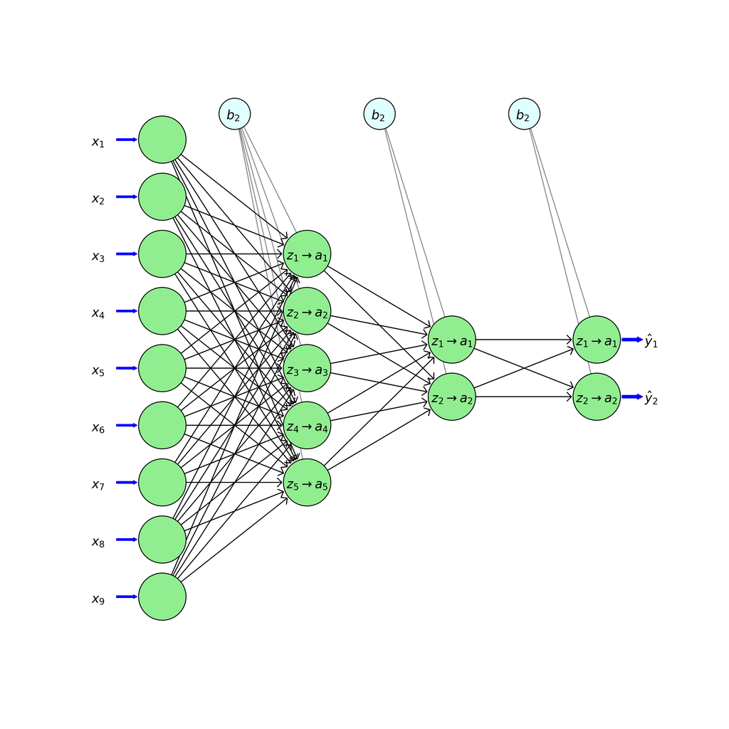